# Using Raster Data in R

## 11.3 Defining & Changing Spatial Projections

### 11.3.1 Define a Spatial Projection

`projection`: Get or set the Cordinate Reference System (CRS) of a Raster* object. It Obtains or Adds information for a Raster object, but doesn’t change the Projection.

```r
r2b
```

```
## class       : RasterLayer
## dimensions  : 10, 10, 100  (nrow, ncol, ncell)
## resolution  : 2, 3  (x, y)
## extent      : 100, 120, -30, 0  (xmin, xmax, ymin, ymax)
## coord. ref. : +proj=longlat +datum=WGS84 +ellps=WGS84 +towgs84=0,0,0
## data source : in memory
## names       : layer
## values      : -0.3952436, 42.14388  (min, max)
```

```r
projection(r2b)
```

```
## [1] "+proj=longlat +datum=WGS84 +ellps=WGS84 +towgs84=0,0,0"
```

```r
r2d = raster(ncol=10, nrow=10, xmn=-1000, xmx=1000, ymn=-100, ymx=900)
r2d  # Provided an strange Spatial Extent, so CRS = NA
```

```
## class       : RasterLayer
## dimensions  : 10, 10, 100  (nrow, ncol, ncell)
## resolution  : 200, 100  (x, y)
## extent      : -1000, 1000, -100, 900  (xmin, xmax, ymin, ymax)
## coord. ref. : NA
```

```r
new.CRS = crs("+proj=lcc +lat_1=48 +lat_2=33 +lon_0=-100 +ellps=WGS84")
projection(r2d) =new.CRS
r2d
```

```
## class       : RasterLayer
## dimensions  : 10, 10, 100  (nrow, ncol, ncell)
## resolution  : 200, 100  (x, y)
## extent      : -1000, 1000, -100, 900  (xmin, xmax, ymin, ymax)
## coord. ref. : +proj=lcc +lat_1=48 +lat_2=33 +lon_0=-100 +ellps=WGS84
```

### 11.3.2 Changing a Spatial Projection

`projectRaster`: Project the values of a Raster* object to a new Raster* object with another projection (i.e. CRS).

It can be done by:

- *Providing the new projection as a single argument*: The function sets the extent and resolution of the new object.
- *Providing a Raster* object with the properties that the input data should be projected to*: Has more control over the transformation (e.g. to assure that the new object lines up with other datasets).

```r
r2b.newCRS = projectRaster(r2b, crs=new.CRS)
r2b
```

```
## class       : RasterLayer
## dimensions  : 10, 10, 100  (nrow, ncol, ncell)
## resolution  : 2, 3  (x, y)
## extent      : 100, 120, -30, 0  (xmin, xmax, ymin, ymax)
## coord. ref. : +proj=longlat +datum=WGS84 +ellps=WGS84 +towgs84=0,0,0
## data source : in memory
## names       : layer
## values      : -0.3952436, 42.14388  (min, max)
```

```r
r2b.newCRS
```

```
## class       : RasterLayer
## dimensions  : 69, 142, 9798  (nrow, ncol, ncell)
## resolution  : 44200, 68200  (x, y)
## extent      : -17765520, -11489120, 12121026, 16826826  (xmin, xmax, ymin, ymax)
## coord. ref. : +proj=lcc +lat_1=48 +lat_2=33 +lon_0=-100 +ellps=WGS84
## data source : in memory
## names       : layer
## values      : -9.323788, 48.29504  (min, max)
```

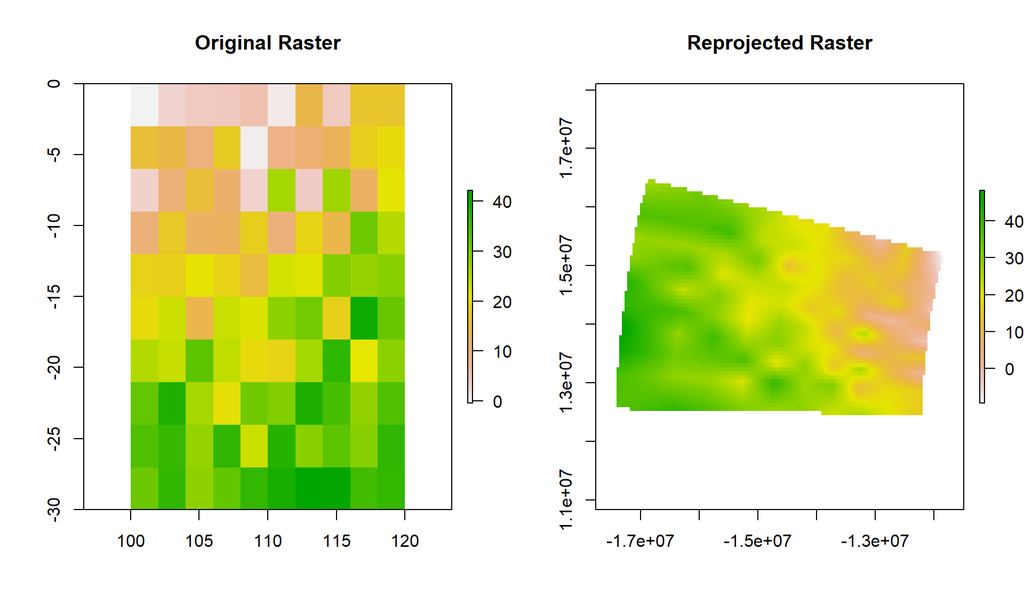

```r
 # Plot the Original and Re-projected Rasters
par(mfrow=c(1,2))
plot(r2b, main="Original Raster")
plot(r2b.newCRS, main="Reprojected Raster")
```

## 11.4 Setting the Spatial Attributes of All Rasters to the same values at once

The Extent, Resolution, and Projection can be set to be the same in all rasters using the `spatial_sync_raster` function from the `spatial.tools` package.